# Guia_3

1. Comprobación empírica de la LGN: caclulalemos promedios utilizando cada vez más datos observaremos el comportamiento del promedio a medida que la cantidad de datos aumenta.

a. Considere una distribución $\mathcal{U}(0,1)$. Indique cuál es el valor verdadero de la media $\mu$.

$\mu= \frac 12$

b. Genere una muestra de tamaño $N=1000$ y para cada $k$ entre $1$ y $1000$ calcule el promedio de las primeras $k$ observaciones. Realice un scatterplot de $k$ vs. promedio. Incluya una linea horizontal en el valor de $y$ correspondiente a la verdadera media $\mu$.

```r
library(repr)
options(repr.plot.width=8,repr.plot.height=4) #controlo el tamaño de la ventana grafica
```

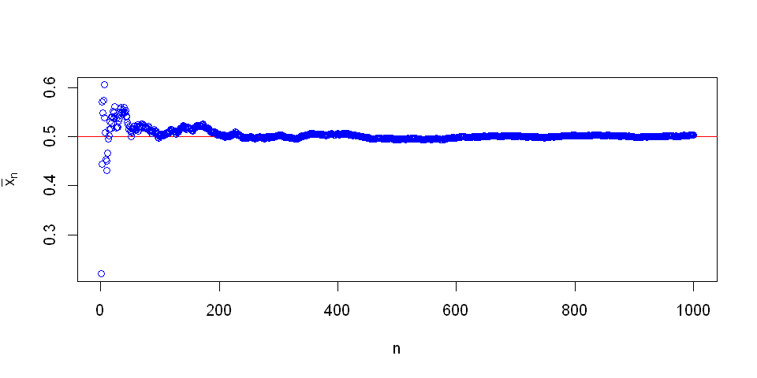

```r
N=1000
promedio<-rep(0,N)
#hago un vector de ceros, tambien podria hacer promedio=c(), pero al hacer =rep(0,ene) reservo solo ene espacios de memoria

set.seed(678)
uniformes=runif(N,0,1) #genero todas las uniformes

for( k in 1:N)
  {
  promedio[k]<-mean(uniformes[1:k]) #promedio las primeras k
}

plot(1:N,promedio,type="n", xlab="n",ylab=expression(bar(x)[n]))
abline(h=0.5,col="red")
points(1:N,promedio,col="blue", pch=1)
```

c. Repetimos b) comenzando con otra semilla y superpongamos el nuevo gráfico utilizando un color diferente. Comparamos los gráficos obtenidos. ¿Qué puede concluir?

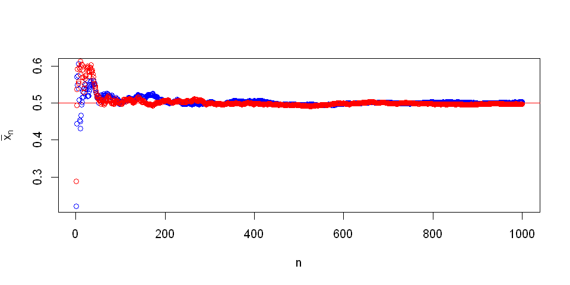

```r
### Repito para superponer gráfico

N=1000
promedio<-rep(0,N)

set.seed(678)
uniformes=runif(N,0,1)

for( k in 1:N)
  {
  promedio[k]<-mean(uniformes[1:k])
}

plot(1:N,promedio,type="n", xlab="n",ylab=expression(bar(x)[n]))
abline(h=0.5,col="red")
points(1:N,promedio,col="blue", pch=1)

#### Ahora hago item c).
set.seed(123)          #fijo  nueva semilla
uniformes=runif(N,0,1) #genero todas las uniformes

for( k in 1:N)
{
  promedio[k]<-mean(uniformes[1:k])
}

points(1:N,promedio,col="red", pch=1)
```

d. Genere ahora datos con una distribución de Cauchy. Recuerde que la distribución Cauchy coincide con la distribución t de Student con un grado de libertad, y su dendsidad está dada por $$ f_X(x)= \frac{1}{\pi (1+x^2)} \,. $$ Observe que es una densidad simétrica alrededor del cero, con colas que acumulan más probabilidad que la normal estándar, y que no tiene esperanza ni varianza finitas. Repita el item b) generando ahora variables con distribución Cauchy, utilizando en R el comando rt(n, df=1). Repita utilizando diferentes semillas. Comente los gráficos obtenidos.

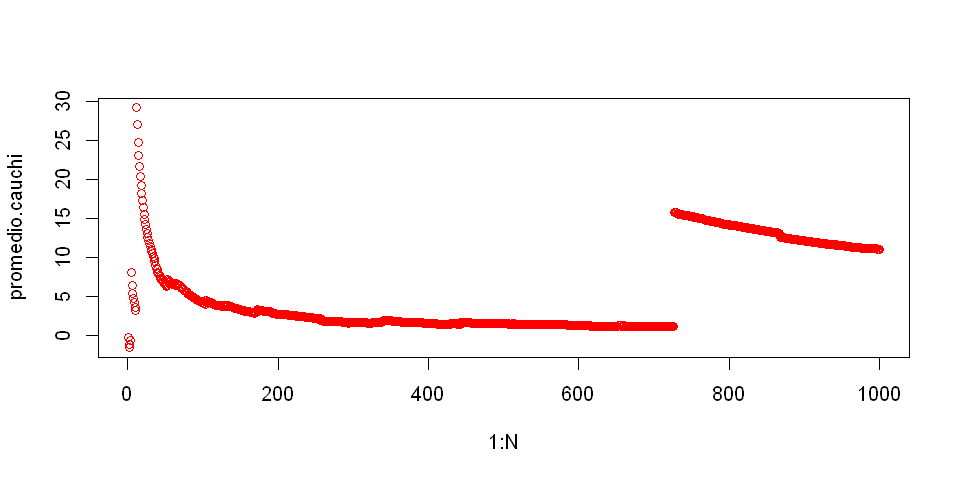

```r
N<-1000
set.seed(123)
cauchi=rt(N,df=1)
promedio.cauchi<-rep(NA, N)
for( k in 1:N){
  promedio.cauchi[k]<-mean(cauchi[1:k])
}
plot(1:N,promedio.cauchi,col="red", pch=1)
```

2.En este ejercicio estudiaremos de manera empírica la distribución del promedio $\bar{X}_n$ de variables $X_1, \ldots, X_n$,  
independientes e idénticamente distribuidas (i.i.d.). Para ello generaremos datos y realizaremos histogramas de promedios $\bar{X}_n$. Es decir, trataremos de interpretar mediante una simulación los resultados de la Ley de los Grandes Números y el Teorema Central del Límite.

a. Caso $n=1$: la variable coincide con el promedio. Genere $Nrep=1000$ datos correspondientes a $X\sim \mathcal U(0; 1)$ y luego haga un histograma con los datos generados. ¿A qué densidad se parece el histograma obtenido?

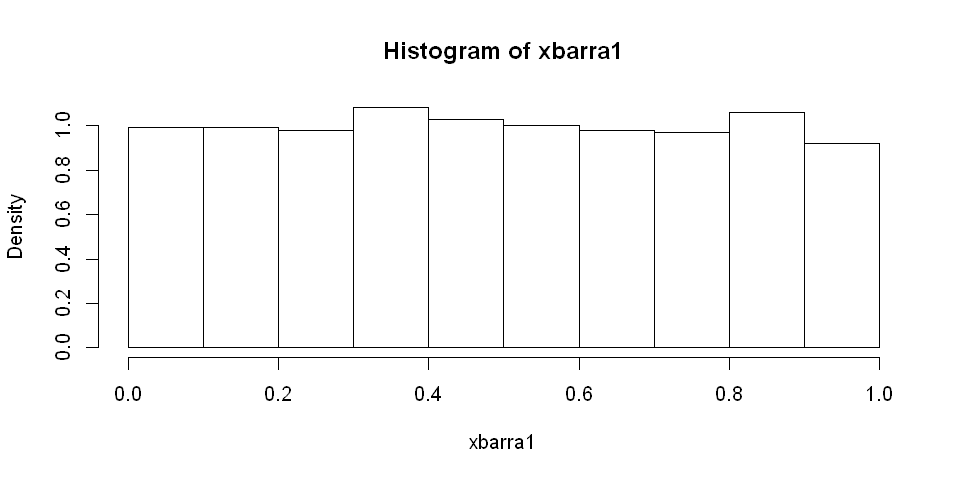

```r
# primero genero 1000 v.a. uniformes y luego hago el histograma.
Nrep=1000
set.seed(123) #fijo la semilla para poder replicar el experimento numerico
u1<-runif(Nrep)
xbarra1=u1
hist(xbarra1,freq=F)
```

Parece una uniforme.

b. Caso $n=2$: Genere $n=2$ datos (independientes) correspondientes a una variable aleatorias con distribución $\mathcal U(0; 1)$ y compute el promedio. Replique $Nrep=1000$ veces y realice un histograma con los $Nrep=1000$ promedios obtenidos. ¿Qué características tiene este histograma?